# ST558 Final Project EDA

Lee Worthington

## Intro

> The dataset used for this analysis is from the Behavioral Risk Factor Surveillance System (BRFSS) of 2015, a health-related telephone survey conducted annually by the Centers for Disease Control and Prevention (CDC). The BRFSS collects data from over 400,000 Americans on health-related risk behaviors, chronic health conditions, and the use of preventative services. For this project Ill focus on the diabetes_binary_health_indicators_BRFSS2015.csv file that contains 253680 survey responses, the main goal is to predict Diabetes_binary which has the levels 0 No diabetes & 1 Prediabetes or diabetes

> There are 21 potential predictors in the data:
> - **HighBP**: High blood pressure (N/Y)
> - **HighChol**: High cholesterol (N/Y)
> - **CholCheck**: Cholesterol check within the past five years (N/Y)
> - **BMI**: Body mass index (numeric)
> - **Smoker**: Smoker status (N/Y)
> - **Stroke**: History of stroke (N/Y)
> - **HeartDiseaseorAttack**: Coronary heart disease or myocardial infarction (N/Y)
> - **PhysActivity**: Physical activity in the past 30 days (N/Y)
> - **Fruits**: Consumption of fruits at least once per day (N/Y)
> - **Veggies**: Consumption of vegetables at least once per day (N/Y)
> - **HvyAlcoholConsump**: Heavy alcohol consumption (N/Y)
> - **AnyHealthcare**: Access to healthcare coverage (N/Y)
> - **NoDocbcCost**: Inability to see a doctor due to cost (N/Y)
> - **GenHlth**: General health status (Excellent/VGood/Good/Fair/Poor)
> - **MentHlth**: Days in the past 30 days when mental health was not good (numeric)
> - **PhysHlth**: Days in the past 30 days when physical health was not good (numeric)
> - **DiffWalk**: Difficulty walking or climbing stairs (N/Y)
> - **Sex**: Gender (F/M)
> - **Age**: Age categories (18-24, 25-29, 30-34, 35-39, 40-44, 45-49, 50-54, 55-59, 60-64, 65-69, 70-74, 75-79, 80+)
> - **Education**: Education level (No School, Elem, Some HS, HS Grad, Some College, College Grad)
> - **Income**: Income categories (<$10k, $10-15k, $15-20k, $20-25k, $25-35k, $35-50k, $50-75k, >$75k)

> The main goal of the EDA here is to get a better idea of the data and to spot potential relationships in the data to hopefully build a model that can accurately predict diabetes based on the available predictors. Since most of the predictors are categorical and there are a large number of them I will mainly focus on understanding the following in the EDA:
> - **Understanding the Data**: How the distributions for each predictor vary based on having or not having diabetes, in order to identify potentially relevant predictors
> - **Checking Data Quality**: ID any potential issues with the data that may require adjustment. That being said my general approach is to not clean or remove data unless im certain its an error, which I don’t think I can be with this data given I know little about the collection process

## Setup environment and data

### Load libraries, set seed

```r
# load libraries
library(tidyverse)
library(GGally)
library(caret)
library(corrplot)
library(reshape2)
library(dplyr)
library(ggplot2)
library(gridExtra)
library(scales)
library(knitr)  # For rendering tables in Quarto

# set seed
set.seed(1)
```

### Get data

```r
# Read in the data https://www.kaggle.com/datasets/alexteboul/diabetes-health-indicators-dataset/
input_data <- read_csv(
  'docker/diabetes_binary_health_indicators_BRFSS2015.csv',
  show_col_types = FALSE
)
```

### Set data types and levels where needed

```r
# Data cleanup
df <- input_data |>
  mutate(
    Diabetes_binary = factor(Diabetes_binary, levels = c(0, 1), labels = c("N", "Y")),
    HighBP = factor(HighBP, levels = c(0, 1), labels = c("N", "Y")),
    HighChol = factor(HighChol, levels = c(0, 1), labels = c("N", "Y")),
    CholCheck = factor(CholCheck, levels = c(0, 1), labels = c("N", "Y")),
    Smoker = factor(Smoker, levels = c(0, 1), labels = c("N", "Y")),
    Stroke = factor(Stroke, levels = c(0, 1), labels = c("N", "Y")),
    HeartDiseaseorAttack = factor(HeartDiseaseorAttack, levels = c(0, 1), labels = c("N", "Y")),
    PhysActivity = factor(PhysActivity, levels = c(0, 1), labels = c("N", "Y")),
    Fruits = factor(Fruits, levels = c(0, 1), labels = c("N", "Y")),
    Veggies = factor(Veggies, levels = c(0, 1), labels = c("N", "Y")),
    HvyAlcoholConsump = factor(HvyAlcoholConsump, levels = c(0, 1), labels = c("N", "Y")),
    AnyHealthcare = factor(AnyHealthcare, levels = c(0, 1), labels = c("N", "Y")),
    NoDocbcCost = factor(NoDocbcCost, levels = c(0, 1), labels = c("N", "Y")),
    GenHlth = factor(GenHlth, levels = c(1, 2, 3, 4, 5), labels = c("Exc", "VGood", "Good", "Fair", "Poor")),
    DiffWalk = factor(DiffWalk, levels = c(0, 1), labels = c("N", "Y")),
    Sex = factor(Sex, levels = c(0, 1), labels = c("F", "M")),
    Age = factor(
      Age,
      levels = 1:13,
      labels = c("18-24", "25-29", "30-34", "35-39", "40-44", "45-49", "50-54", "55-59", "60-64", "65-69", "70-74", "75-79", "80+")
    ),
    Education = factor(
      Education,
      levels = 1:6,
      labels = c(
        "None/Kinder", "Elem", "Some HS",
        "HS Grad", "Some College", "College Grad"
      )
    ),
    Income = factor(
      Income,
      levels = 1:8,
      labels = c(
        "<$10k", "$10-15k", "$15-20k", "$20-25k",
        "$25-35k", "$35-50k", "$50-75k", ">$75k"
      )
    )
  )
```

## EDA

### Print summary results

```r
summary(df)
```

```
 Diabetes_binary HighBP     HighChol   CholCheck       BMI        Smoker
 N:218334        N:144851   N:146089   N:  9470   Min.   :12.00   N:141257
 Y: 35346        Y:108829   Y:107591   Y:244210   1st Qu.:24.00   Y:112423
                                                  Median :27.00
                                                  Mean   :28.38
                                                  3rd Qu.:31.00
                                                  Max.   :98.00

 Stroke     HeartDiseaseorAttack PhysActivity Fruits     Veggies
 N:243388   N:229787             N: 61760     N: 92782   N: 47839
 Y: 10292   Y: 23893             Y:191920     Y:160898   Y:205841





 HvyAlcoholConsump AnyHealthcare NoDocbcCost  GenHlth         MentHlth
 N:239424          N: 12417      N:232326    Exc  :45299   Min.   : 0.000
 Y: 14256          Y:241263      Y: 21354    VGood:89084   1st Qu.: 0.000
                                             Good :75646   Median : 0.000
                                             Fair :31570   Mean   : 3.185
                                             Poor :12081   3rd Qu.: 2.000
                                                           Max.   :30.000

    PhysHlth      DiffWalk   Sex             Age               Education
 Min.   : 0.000   N:211005   F:141974   60-64  :33244   None/Kinder :   174
 1st Qu.: 0.000   Y: 42675   M:111706   65-69  :32194   Elem        :  4043
 Median : 0.000                         55-59  :30832   Some HS     :  9478
 Mean   : 4.242                         50-54  :26314   HS Grad     : 62750
 3rd Qu.: 3.000                         70-74  :23533   Some College: 69910
 Max.   :30.000                         45-49  :19819   College Grad:107325
                                        (Other):87744
     Income
 >$75k  :90385
 $50-75k:43219
 $35-50k:36470
 $25-35k:25883
 $20-25k:20135
 $15-20k:15994
 (Other):21594
```

```r
sapply(df, function(x) sum(is.na(x)))
```

```
     Diabetes_binary               HighBP             HighChol
                   0                    0                    0
           CholCheck                  BMI               Smoker
                   0                    0                    0
              Stroke HeartDiseaseorAttack         PhysActivity
                   0                    0                    0
              Fruits              Veggies    HvyAlcoholConsump
                   0                    0                    0
       AnyHealthcare          NoDocbcCost              GenHlth
                   0                    0                    0
            MentHlth             PhysHlth             DiffWalk
                   0                    0                    0
                 Sex                  Age            Education
                   0                    0                    0
              Income
                   0
```

### Code for plots

```r
# plot pairs
#GGally::ggpairs(df, columns = c(1, 2, 3, 4))  # Mosts of these are ahrd to read and not very informative, use custom plots instead

# Define different variable types
factor_vars_heatmap <- c(
  "HighBP", "HighChol", "CholCheck", "Smoker", "Stroke", "HeartDiseaseorAttack",
  "PhysActivity", "Fruits", "Veggies", "HvyAlcoholConsump", "AnyHealthcare",
  "NoDocbcCost", "DiffWalk", "Sex"
)
factor_vars_histogram <- c("GenHlth", "Age", "Education", "Income")
numeric_vars <- c("BMI", "MentHlth", "PhysHlth")

# Function to generate heatmap for confusion matrix of factor variables
generate_heatmap <- function(var) {
  confusion <- table(df$Diabetes_binary, df[[var]])
  confusion_melted <- melt(confusion)
  confusion_melted$percentage <- confusion_melted$value / sum(confusion_melted$value) * 100
  confusion_melted$label <- paste(comma(confusion_melted$value), sprintf("(%.1f%%)", confusion_melted$percentage))

  ggplot(confusion_melted, aes(Var1, Var2, fill = value)) +
    geom_tile(alpha = 0.5) +
    geom_text(aes(label = label), color = "black") +
    scale_fill_gradient(low = "lightgreen", high = "darkgreen") +
    labs(title = paste("Confusion Matrix for", var),
         x = "Diabetes_binary",
         y = var,
         fill = "Count") +
    theme_minimal() +
    scale_x_discrete(labels = c("0", "1")) +
    scale_y_discrete(labels = c("0", "1"))
}

# Function to generate histogram for numeric variables with log scale on x-axis
generate_histogram_numeric <- function(var) {
  ggplot(df, aes_string(x = var, fill = "Diabetes_binary")) +
    geom_histogram(position = "identity", alpha = 0.5, bins = 30) +
    #scale_x_log10() +
    labs(title = paste("Histogram of", var, "partitioned by Diabetes_binary (Log Scale)"), x = var, y = "Count") +
    theme_minimal()
}

# Function to generate boxplot for numeric variables
generate_boxplot_numeric <- function(var) {
  ggplot(df, aes(x = Diabetes_binary, y = df[[var]], fill = Diabetes_binary)) +
    geom_boxplot(alpha = 0.5) +
    scale_y_log10() +
    labs(title = paste("Boxplot of", var, "partitioned by Diabetes_binary"), x = "Diabetes_binary", y = var) +
    theme_minimal()
}

# Function to generate bar plot for factor variables with more than 3 levels
generate_histogram_factor <- function(var) {
  df |>
    group_by(!!sym(var), Diabetes_binary) |>

    summarise(count = n(), .groups = "drop") |>

    group_by(!!sym(var)) |>

    mutate(
      percentage = count / sum(count) * 100,
      label = paste0(sprintf("%.1f", percentage), "%")
    ) |>

    ggplot(aes_string(x = var, y = "count", fill = "Diabetes_binary")) +
    geom_bar(position = "stack", stat = "identity", alpha = 0.5) +
    geom_text(aes(label = label), position = position_stack(vjust = 0.5), color = "black") +
    labs(title = paste("Bar Plot of", var, "partitioned by Diabetes_binary"), x = var, y = "Count") +
    theme_minimal() +
    theme(axis.text.x = element_text(angle = 45, hjust = 1))
}
```

### Generate plots

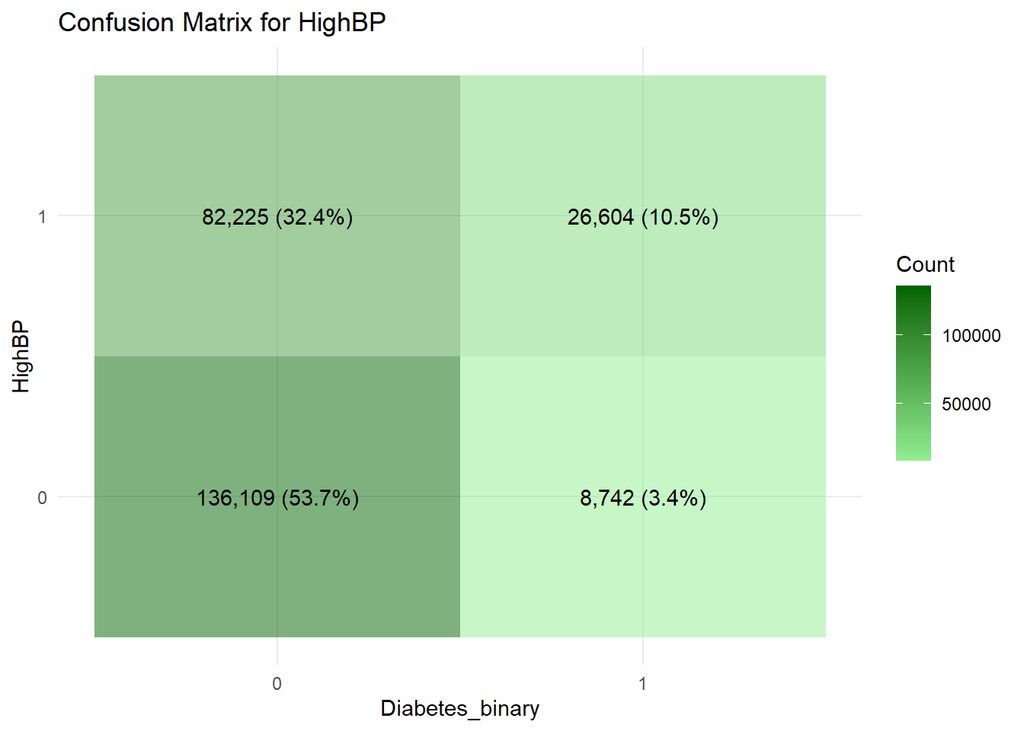

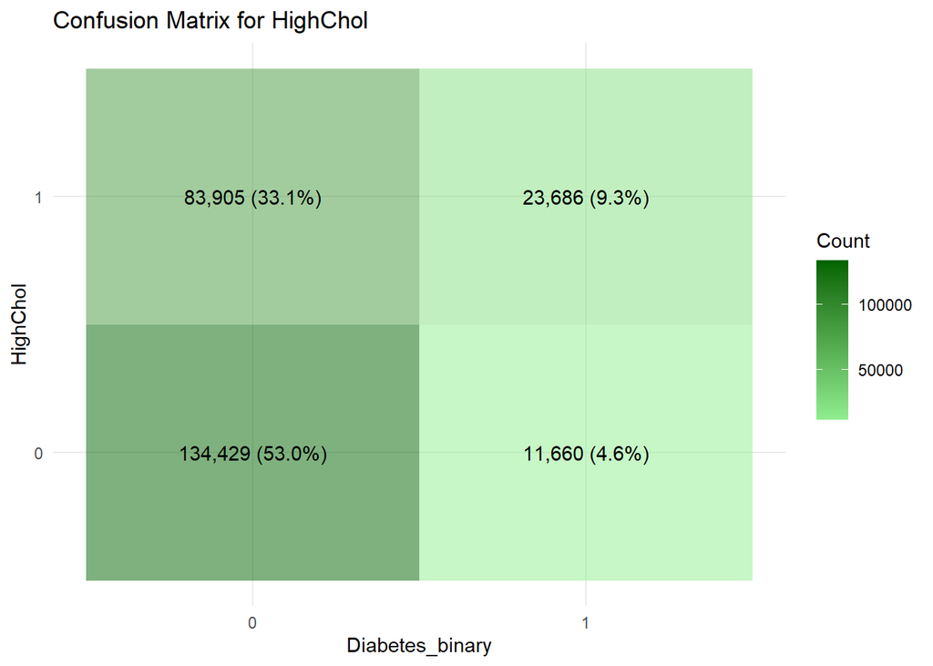

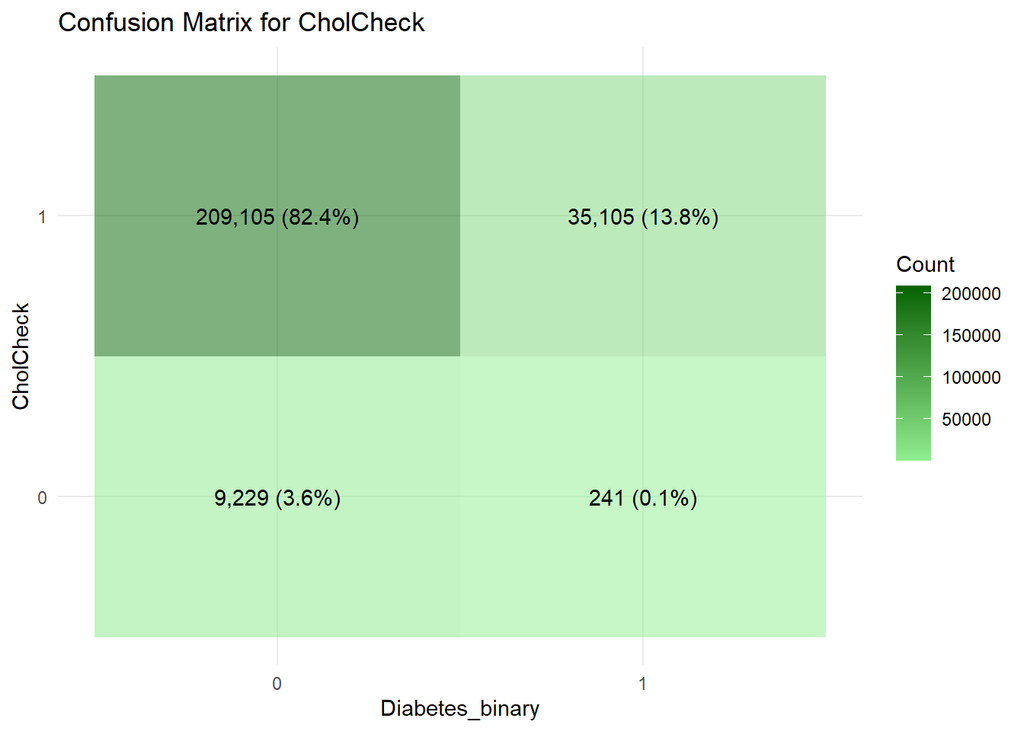

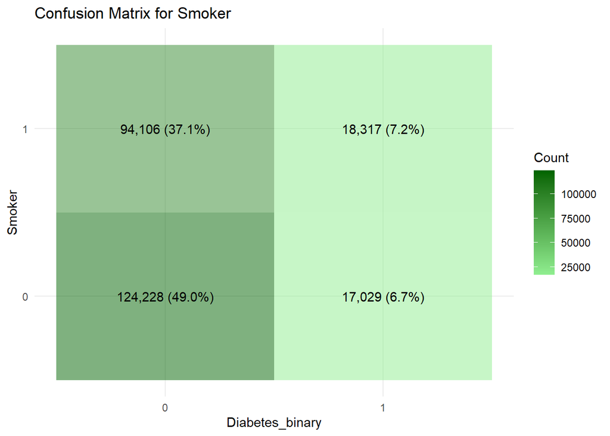

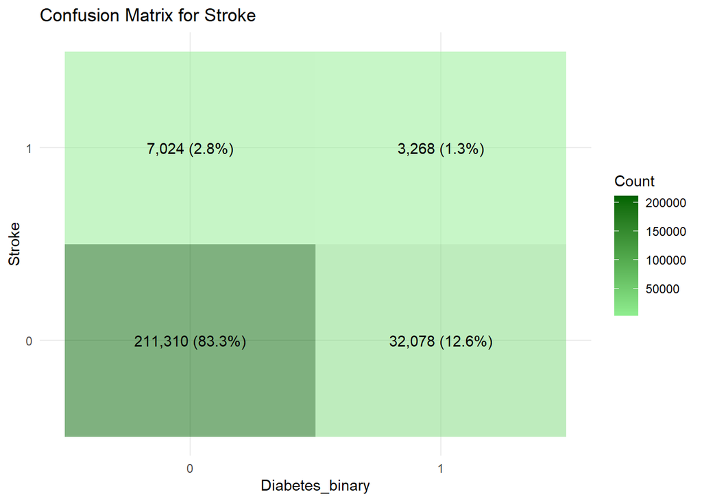

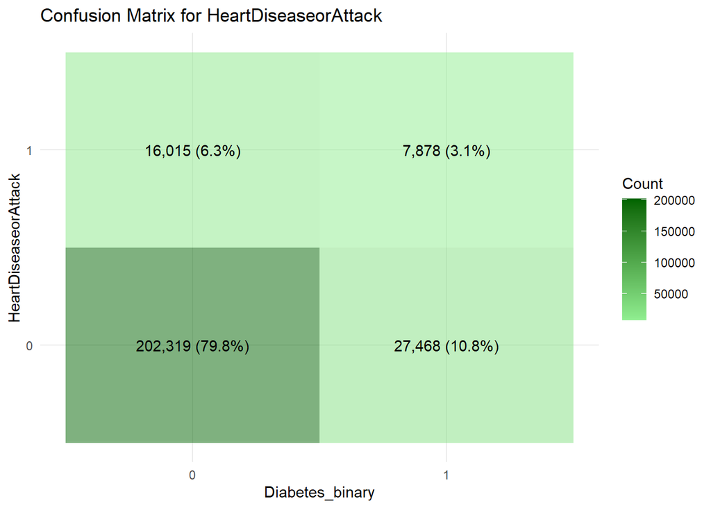

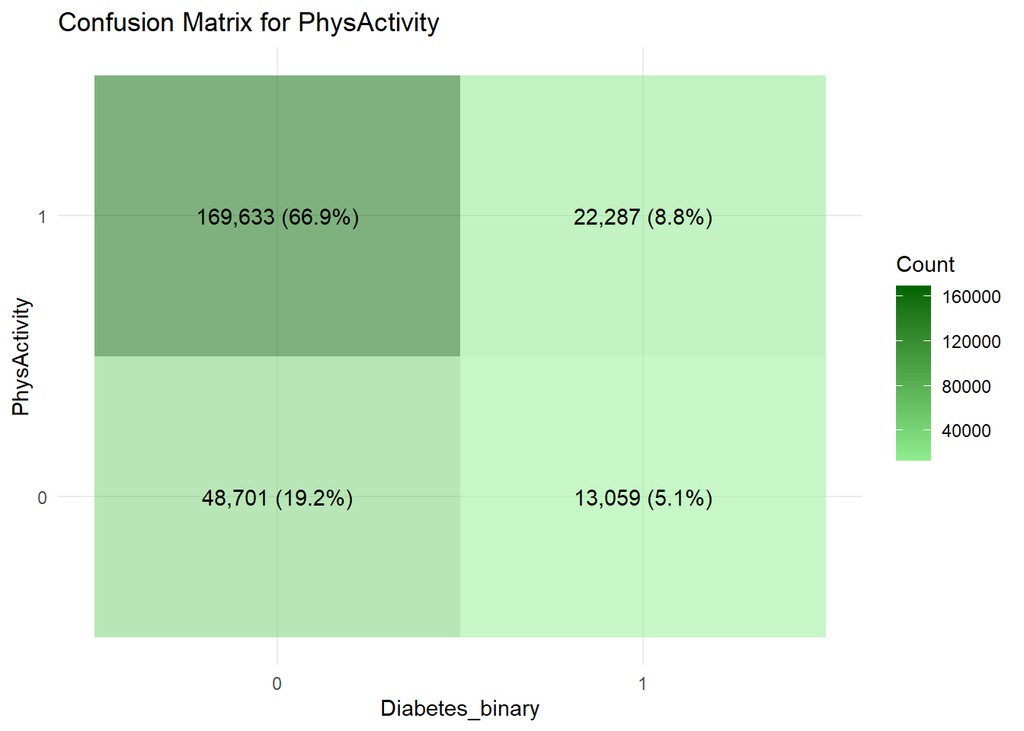

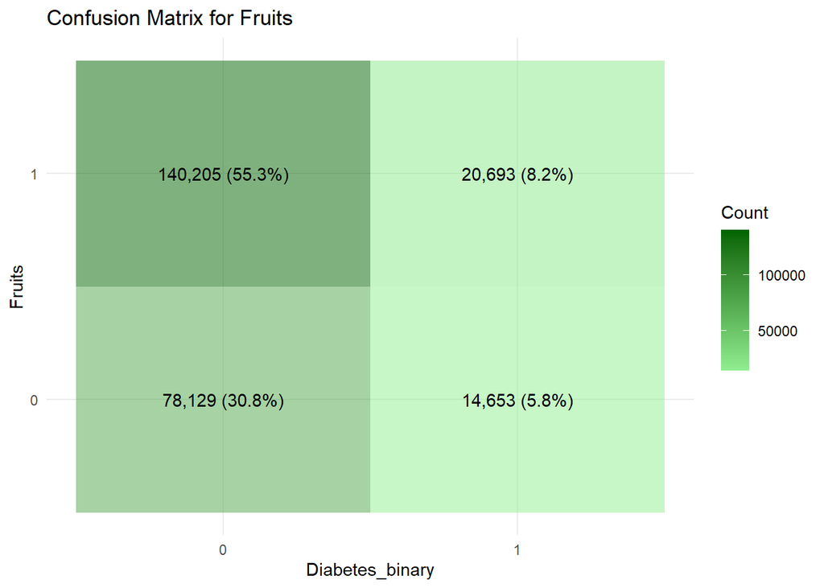

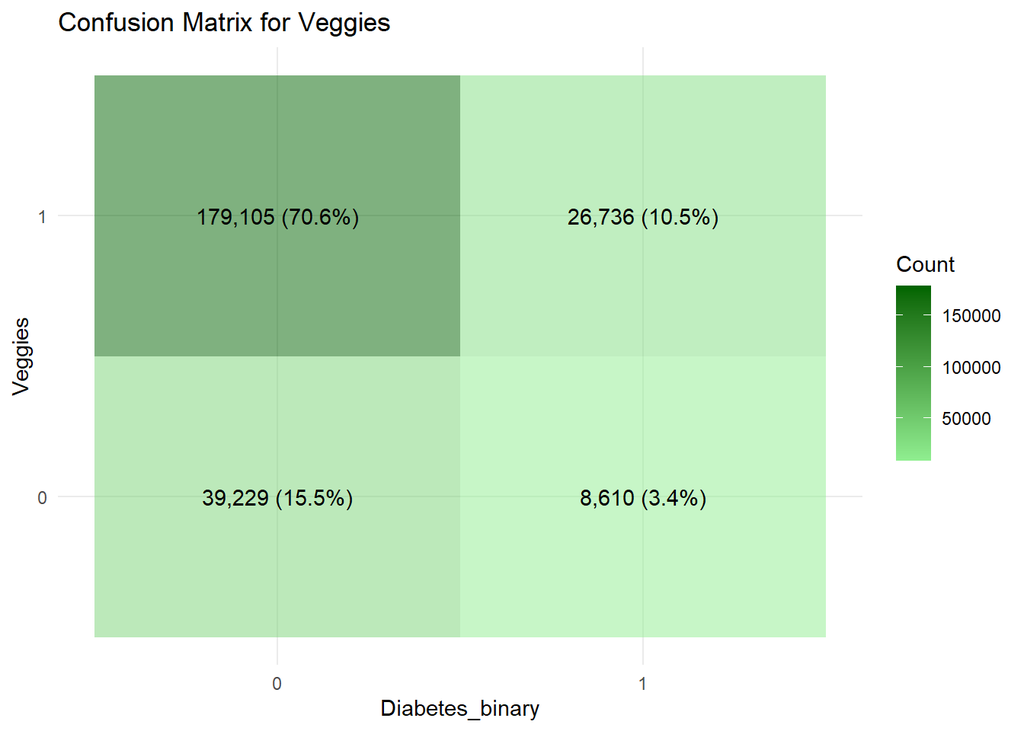

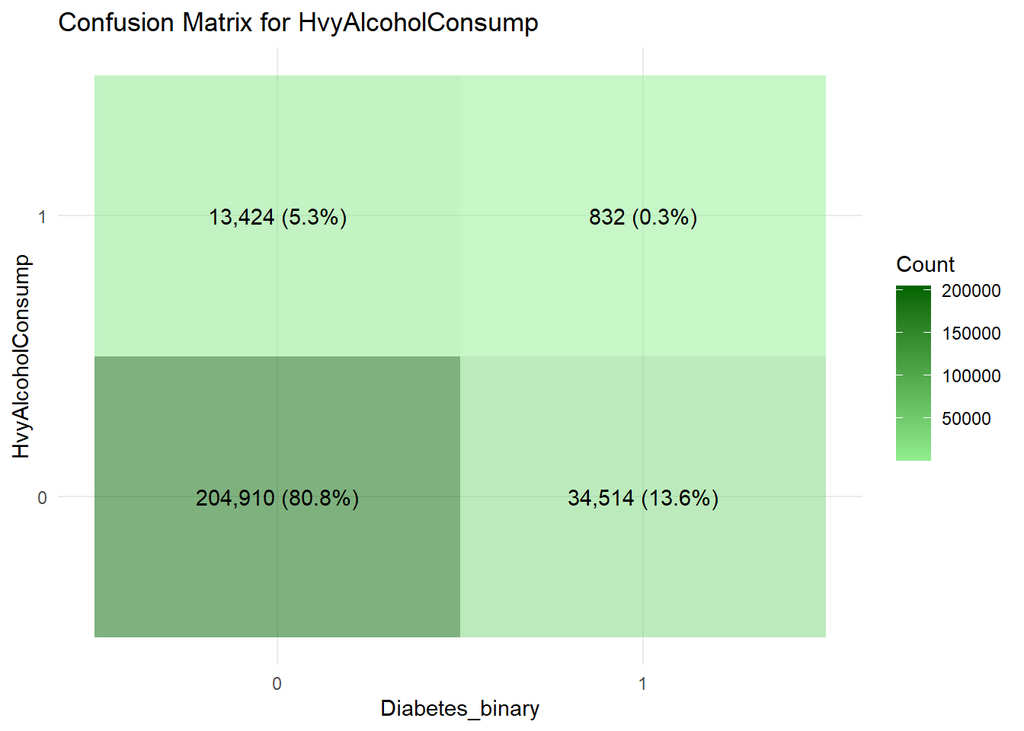

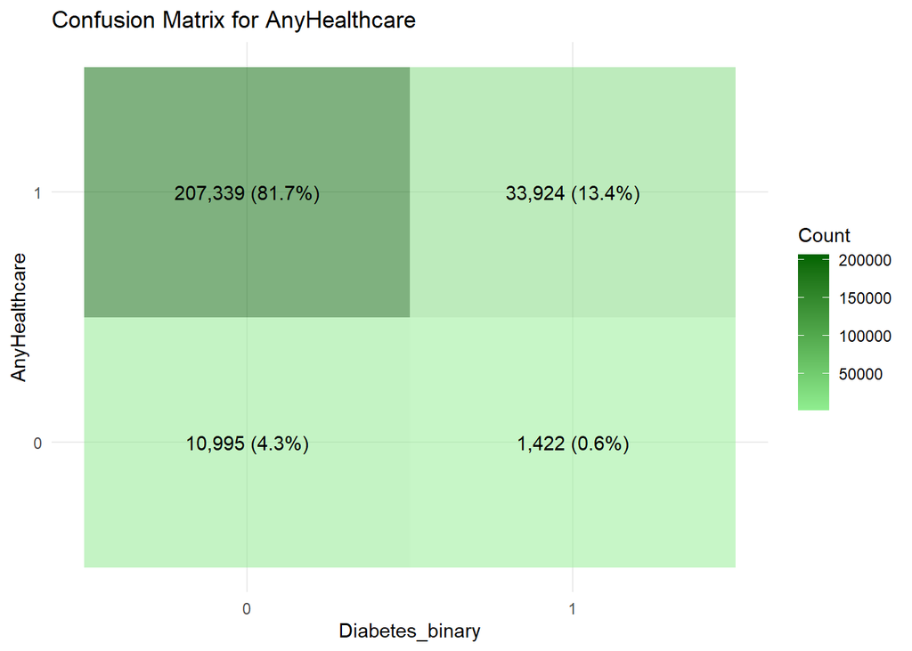

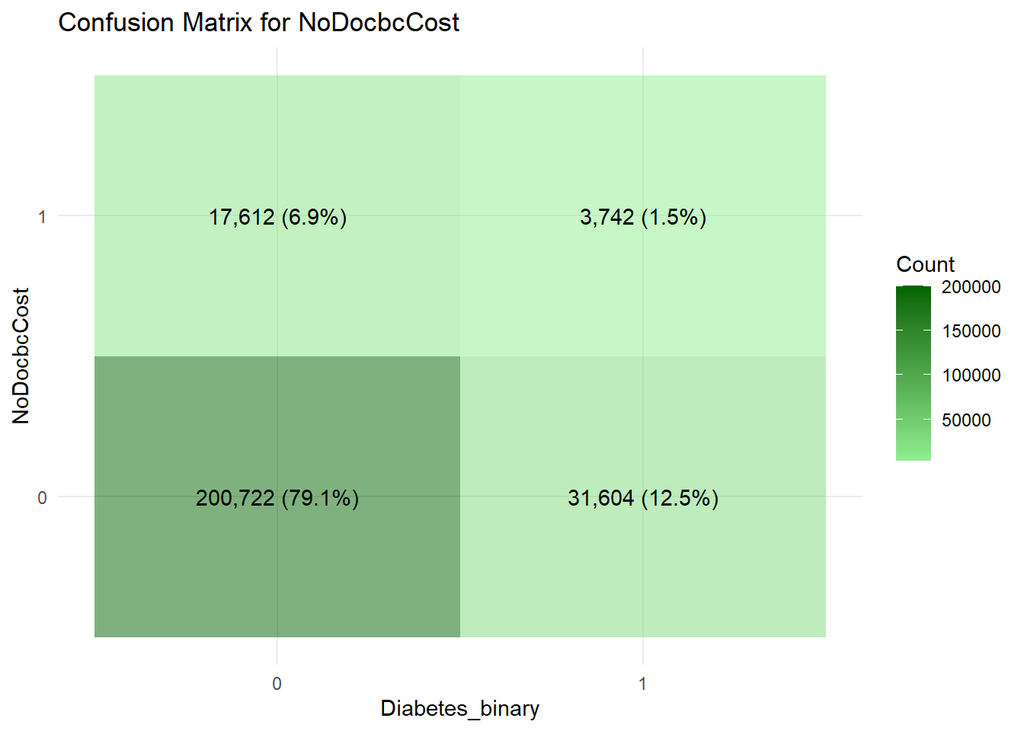

[2 more figures not shown]

```r
# Generate heatmaps for factor variables with up to 3 levels
for (var in factor_vars_heatmap) {
  print(generate_heatmap(var))
}
```

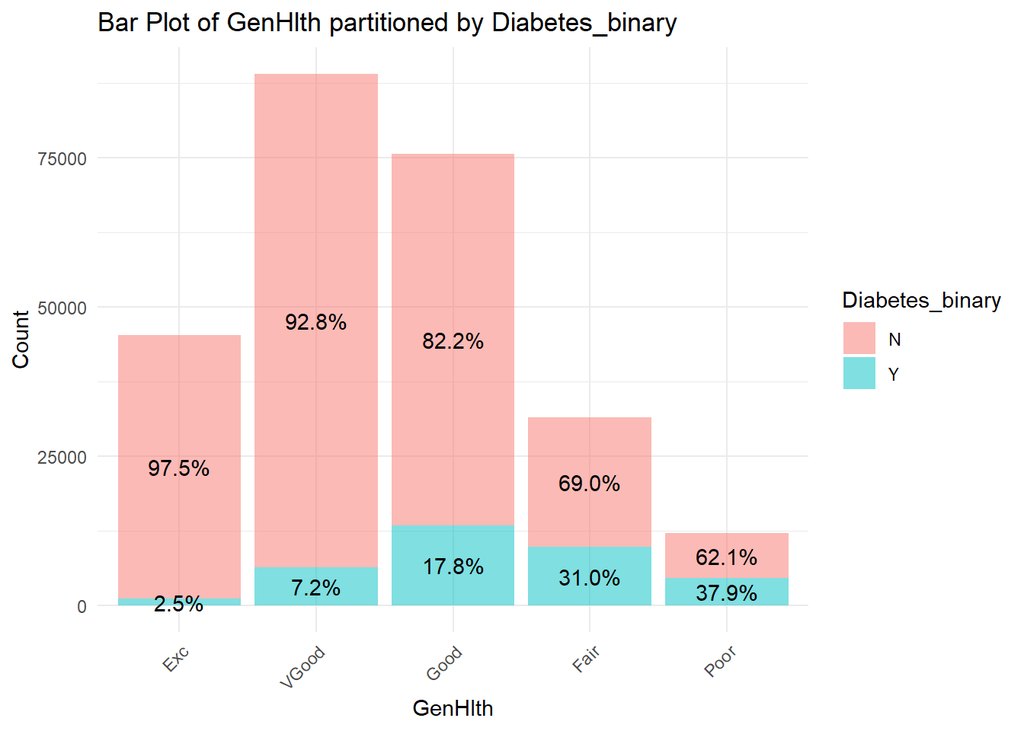

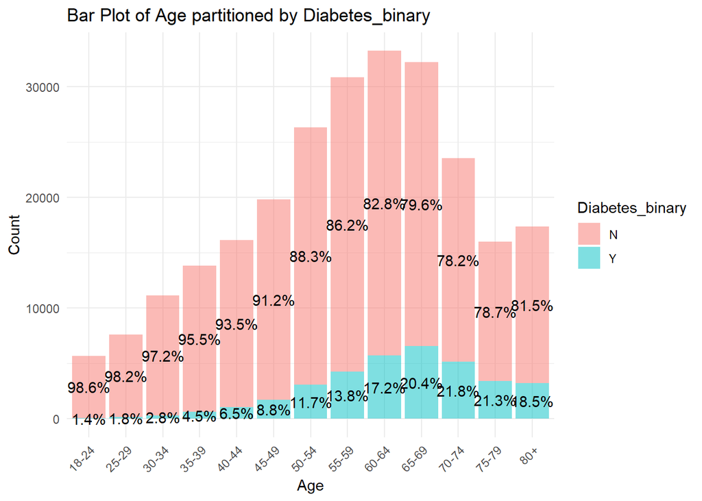

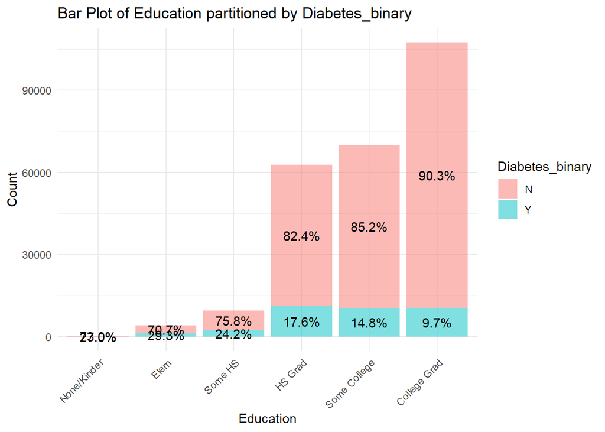

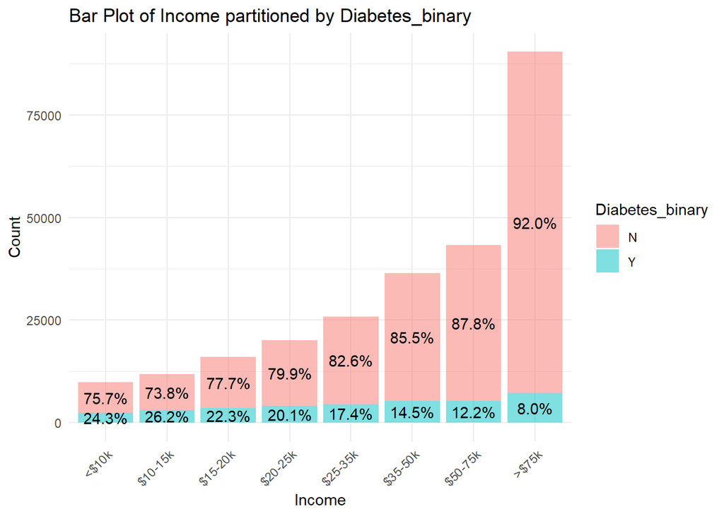

```r
# Generate histograms for factor variables with more than 3 levels
for (var in factor_vars_histogram) {
  print(generate_histogram_factor(var))
}
```

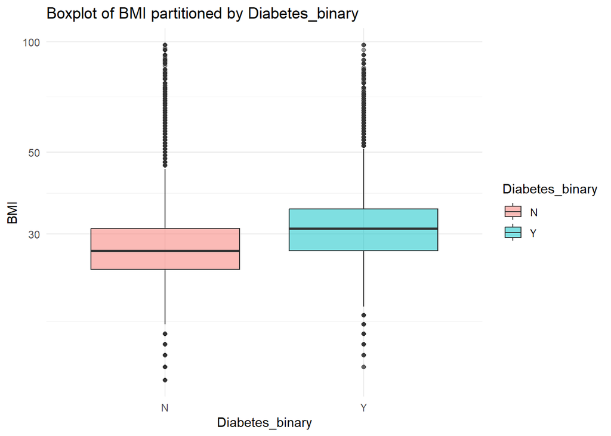

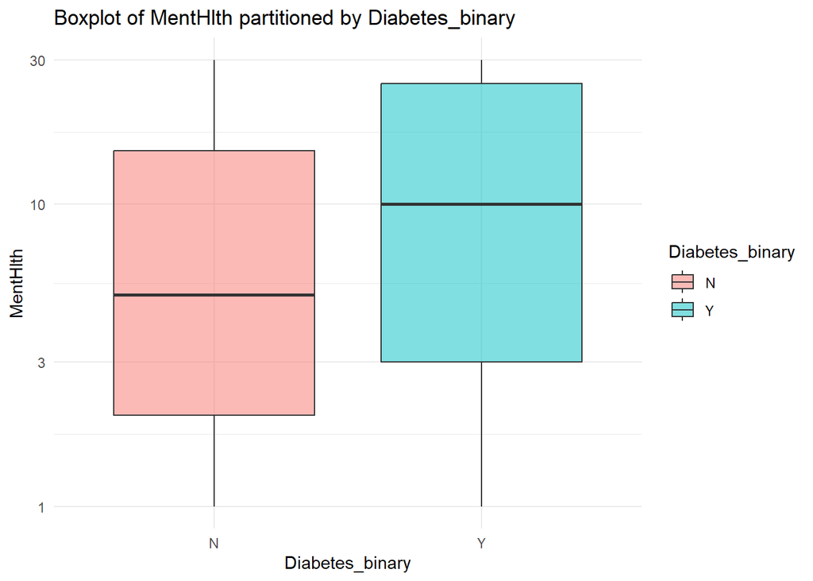

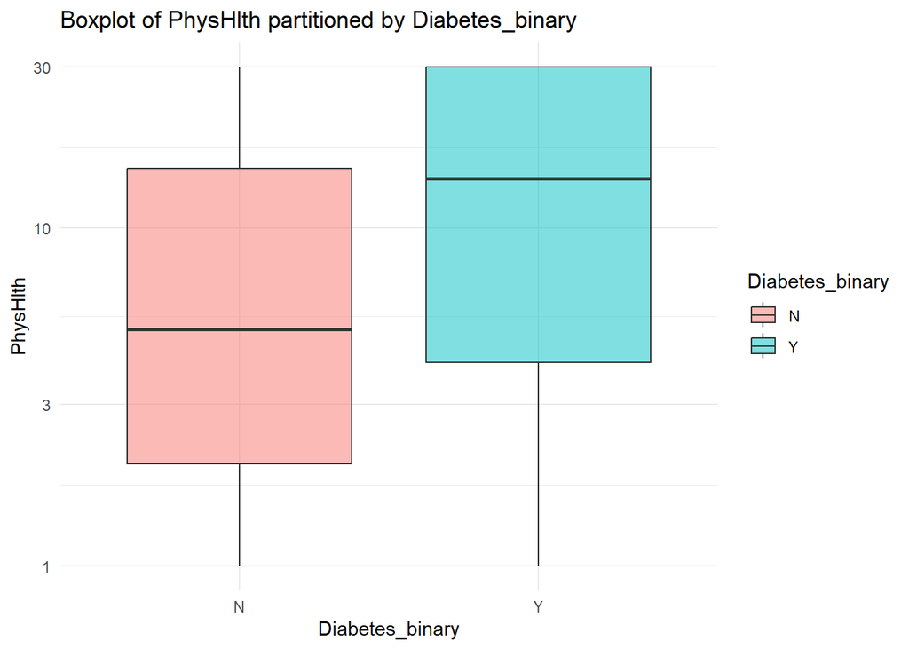

```r
# Generate histograms and box-plots for numeric variables with log scale on x-axis
for (var in numeric_vars) {
  #print(generate_histogram_numeric(var))
  print(generate_boxplot_numeric(var))
}
```

> Given the large number of potential predictors and many of them being categorical running all the pair plots is hard to interpret so I’ll focus on plotting predictors relationships with the response instead. Based on the plots above:
> - In the boxplots we can see that having poor mental and physical health for prolonged periods of time seems to increase diabetes risk
> - Higher BMI also seems to be indicative of higher diabetes risk as the distribution for pre-diabetes generally has larger related BMI values
> - Lower income also seems to be associated with a much higher risk of diabetes as generally the higher the income the lower the proportion of diabetes
> - Higher education level seems to be associated with lower diabetes risk based on the proportions
> - Increased age also seems to lead to increased diabetes risk
> - Having high blood pressure and high cholestoral seem to increase diabetes risk
> - Low general health also seems to be associated with higher diabetes risk
> - Overall there look to be a number of potentially strong predictors, but the most impactful seem to be MentHlth PhysHlth GenHlth BMI Income Education Age HighBP HighChol

Click here for the modeling page: [Modeling Page](https://law5097.github.io/ST558_FinalProject/Modeling.html)